# MSstats PSM-Level Proteomics Analysis

lionakism-20250630-NPW1 example dataset excluding sample F22

Author

Kevin Cormier

Published

August 31, 2026

```r
required_packages <- c(
  "MSstats",
  "readxl",
  "dplyr",
  "tidyr",
  "stringr",
  "purrr",
  "ggplot2",
  "ggrepel",
  "scales",
  "EnhancedVolcano",
  "ggbreak",
  "readr",
  "DT",
  "knitr",
  "tibble",
  "clusterProfiler",
  "AnnotationDbi",
  "org.Hs.eg.db",
  "enrichplot",
  "htmltools"
)

missing_packages <- required_packages[!vapply(required_packages, requireNamespace, logical(1), quietly = TRUE)]
if (length(missing_packages) > 0) {
  stop("Install required package(s): ", paste(missing_packages, collapse = ", "), call. = FALSE)
}

suppressPackageStartupMessages({
  library(MSstats)
  library(readxl)
  library(dplyr)
  library(tidyr)
  library(stringr)
  library(purrr)
  library(ggplot2)
  library(EnhancedVolcano)
  library(ggbreak)
  library(readr)
  library(DT)
  library(knitr)
  library(tibble)
})

current_input <- tryCatch(knitr::current_input(), error = function(e) NULL)
report_dir <- if (!is.null(current_input) && nzchar(current_input)) {
  dirname(normalizePath(current_input, winslash = "/", mustWork = TRUE))
} else {
  normalizePath(getwd(), winslash = "/", mustWork = TRUE)
}

psm_file <- normalizePath(file.path(params$psm_file), winslash = "/", mustWork = TRUE)
annotation_file <- normalizePath(file.path(report_dir, params$annotation_file), winslash = "/", mustWork = TRUE)
output_dir <- file.path(report_dir, params$output_dir)
dir.create(output_dir, recursive = TRUE, showWarnings = FALSE)
read_psm_n_max <- if (is.null(params$max_psm_rows)) Inf else params$max_psm_rows
source(file.path(report_dir, "pathway-analysis-functions.R"), local = knitr::knit_global())
source(file.path(report_dir, "qc-helper-functions.R"), local = knitr::knit_global())

figure_dir <- file.path(report_dir, "..", "figures")
dir.create(figure_dir, recursive = TRUE, showWarnings = FALSE)
knitr::opts_chunk$set(
  fig.path = paste0("../figures/", params$request, "-"),
  dev = c("png", "pdf"),
  dpi = 150
)

set.seed(20250707)
```

## Methods

Proteome Discoverer fields were converted with `MSstats::PDtoMSstatsFormat()`, resolving duplicate feature measurements by their maximum intensity. Intensities were log2 transformed, normalized by equalizeMedians, summarized from peptide features to proteins with the TMP method, and missing values were handled using MSstats model-based imputation. Quality assessment included run-level feature counts and intensity distributions, missingness, coefficients of variation, Pearson correlations, and principal component analysis.

Protein-level linear models tested FC versus Healthy, LC versus Healthy, and LC versus FC. The Infected-versus-Healthy contrast represented the equally weighted mean of FC and LC minus Healthy. MSstats supplied log2 fold changes, standard errors, test statistics, degrees of freedom, raw p-values, and Benjamini-Hochberg adjusted p-values. Differential expression was defined as an adjusted p-value below 0.05 and an absolute log2 fold change of at least 1.

For GO Biological Process gene set enrichment analysis (GSEA), UniProt protein accessions were mapped to Entrez identifiers and ranked by signed statistical evidence. Gene sets containing 100 to 500 genes were tested with clusterProfiler; results were interpreted using Benjamini-Hochberg adjusted p-values and summarized in dot plots, similarity tree plots, and result tables. Power diagnostics used a two-sided alpha of 0.05, target power of 0.8, and target absolute effect of 1 log2 units.

```r
psm_raw <- readxl::read_excel(
  psm_file,
  sheet = "PSMs",
  .name_repair = "minimal",
  n_max = read_psm_n_max
)

annotation_raw <- readxl::read_excel(annotation_file, .name_repair = "minimal")

required_psm_cols <- c(
  "File ID",
  "Annotated Sequence",
  "Charge",
  "Master Protein Accessions",
  "Quan Value"
)
required_annotation_cols <- c("File Name", "File ID", "Condition", "BioReplicate")

missing_psm_cols <- setdiff(required_psm_cols, names(psm_raw))
missing_annotation_cols <- setdiff(required_annotation_cols, names(annotation_raw))
if (length(missing_psm_cols) > 0) {
  stop("Missing required PSM column(s): ", paste(missing_psm_cols, collapse = "; "), call. = FALSE)
}
if (length(missing_annotation_cols) > 0) {
  stop("Missing required annotation column(s): ", paste(missing_annotation_cols, collapse = "; "), call. = FALSE)
}

psm <- psm_raw |>
  rename(SpectrumFile = `File ID`) |>
  mutate(
    SpectrumFile = as.character(SpectrumFile),
    `Quan Value` = suppressWarnings(as.numeric(`Quan Value`))
  )

annotation <- annotation_raw |>
  rename(Run = `File ID`) |>
  mutate(
    Run = as.character(Run),
    Condition = as.character(Condition),
    BioReplicate = as.character(BioReplicate),
    SampleName = tools::file_path_sans_ext(basename(as.character(`File Name`))),
    FigureLabel = .data$SampleName
  )

excluded_runs <- as.character(params$excluded_runs)
excluded_runs <- excluded_runs[!is.na(excluded_runs) & nzchar(excluded_runs)]
if (length(excluded_runs) > 0) {
  missing_excluded_runs <- setdiff(excluded_runs, annotation$Run)
  if (length(missing_excluded_runs) > 0) {
    warning("Excluded run(s) were not found in annotation: ",
            paste(missing_excluded_runs, collapse = ", "))
  }

  psm <- psm |>
    filter(!.data$SpectrumFile %in% excluded_runs)
  annotation <- annotation |>
    filter(!.data$Run %in% excluded_runs)
}

missing_runs <- setdiff(unique(psm$SpectrumFile), annotation$Run)
if (length(missing_runs) > 0) {
  stop("Missing annotation for run(s): ", paste(missing_runs, collapse = ", "), call. = FALSE)
}
```

```r
as_plain_tibble <- function(x) {
  tibble::as_tibble(as.data.frame(x))
}

first_existing_col <- function(data, candidates) {
  found <- intersect(candidates, names(data))
  if (length(found) == 0) NULL else found[[1]]
}

is_truthy_flag <- function(x) {
  if (is.logical(x)) return(!is.na(x) & x)
  vals <- tolower(trimws(as.character(x)))
  !is.na(vals) & vals %in% c("true", "t", "yes", "y", "1", "+")
}

has_modification <- function(x) {
  vals <- tolower(trimws(as.character(x)))
  !is.na(vals) & nzchar(vals) &
    !vals %in% c("none", "unmodified", "no modifications", "na")
}

add_psm_feature_id <- function(data) {
  data |>
    mutate(
      .qc_feature_id = paste(
        .data$`Master Protein Accessions`,
        .data$`Annotated Sequence`,
        .data$Charge,
        sep = " | "
      )
    )
}

coerce_log2_intensity <- function(x, value_col) {
  vals <- suppressWarnings(as.numeric(x))
  finite_vals <- vals[is.finite(vals)]
  if (length(finite_vals) == 0) return(vals)

  looks_linear <- grepl("^Intensity$|Quan Value", value_col, ignore.case = TRUE) ||
    stats::median(finite_vals, na.rm = TRUE) > 100

  if (looks_linear) {
    log2(pmax(vals, .Machine$double.xmin))
  } else {
    vals
  }
}

impute_matrix_by_row_mean <- function(mat) {
  if (nrow(mat) == 0 || ncol(mat) == 0) return(mat)

  keep <- rowSums(is.finite(mat)) >= 2
  mat <- mat[keep, , drop = FALSE]
  if (nrow(mat) == 0) return(mat)

  row_means <- rowMeans(mat, na.rm = TRUE)
  for (i in seq_len(nrow(mat))) {
    mat[i, !is.finite(mat[i, ])] <- row_means[[i]]
  }

  row_vars <- apply(mat, 1, stats::var, na.rm = TRUE)
  mat[is.finite(row_vars) & row_vars > 0, , drop = FALSE]
}

make_feature_run_matrix <- function(data, feature_col, run_col, value_col,
                                    max_features = params$qc_max_features) {
  matrix_data <- data |>
    mutate(
      .qc_feature = as.character(.data[[feature_col]]),
      .qc_run = as.character(.data[[run_col]]),
      .qc_log2 = coerce_log2_intensity(.data[[value_col]], value_col)
    ) |>
    filter(!is.na(.data$.qc_feature), nzchar(.data$.qc_feature),
           !is.na(.data$.qc_run), nzchar(.data$.qc_run),
           is.finite(.data$.qc_log2)) |>
    group_by(.data$.qc_feature, .data$.qc_run) |>
    summarise(log2Intensity = mean(.data$.qc_log2, na.rm = TRUE),
              .groups = "drop")

  if (nrow(matrix_data) == 0) return(matrix(numeric(), nrow = 0, ncol = 0))

  selected_features <- matrix_data |>
    group_by(.data$.qc_feature) |>
    summarise(
      n_runs = n_distinct(.data$.qc_run),
      variance = stats::var(.data$log2Intensity, na.rm = TRUE),
      .groups = "drop"
    ) |>
    mutate(variance = if_else(is.finite(.data$variance), .data$variance, 0)) |>
    arrange(desc(.data$n_runs), desc(.data$variance)) |>
    slice_head(n = max_features) |>
    pull(.data$.qc_feature)

  wide <- matrix_data |>
    filter(.data$.qc_feature %in% selected_features) |>
    tidyr::pivot_wider(
      names_from = ".qc_run",
      values_from = "log2Intensity"
    )

  mat <- wide |>
    tibble::column_to_rownames(".qc_feature") |>
    as.matrix()
  storage.mode(mat) <- "numeric"
  mat
}

plot_correlation_heatmap <- function(feature_matrix, sample_annotation, title) {
  if (ncol(feature_matrix) < 2 || nrow(feature_matrix) < 2) {
    message("Correlation heatmap skipped: not enough quantified features or runs.")
    return(invisible(NULL))
  }

  mat <- impute_matrix_by_row_mean(feature_matrix)
  if (ncol(mat) < 2 || nrow(mat) < 2) {
    message("Correlation heatmap skipped: not enough complete features after imputation.")
    return(invisible(NULL))
  }

  corr <- stats::cor(mat, use = "pairwise.complete.obs")
  corr_df <- as.data.frame(as.table(corr), stringsAsFactors = FALSE)
  names(corr_df) <- c("Run1", "Run2", "Correlation")

  correlation_annotation <- sample_annotation |>
    mutate(
      CorrelationLabel = if_else(
        !is.na(.data$Condition) & nzchar(.data$Condition) &
          !is.na(.data$BioReplicate) & nzchar(as.character(.data$BioReplicate)),
        paste0(.data$Condition, "_", .data$BioReplicate),
        coalesce(.data$FigureLabel, .data$Run)
      )
    )
  label_lookup <- stats::setNames(
    correlation_annotation$CorrelationLabel,
    correlation_annotation$Run
  )
  display_levels <- unname(label_lookup[colnames(mat)])
  display_levels[is.na(display_levels)] <- colnames(mat)[is.na(display_levels)]
  corr_df <- corr_df |>
    mutate(
      Sample1 = coalesce(unname(label_lookup[as.character(.data$Run1)]), as.character(.data$Run1)),
      Sample2 = coalesce(unname(label_lookup[as.character(.data$Run2)]), as.character(.data$Run2)),
      Sample1 = factor(.data$Sample1, levels = unique(display_levels)),
      Sample2 = factor(.data$Sample2, levels = unique(display_levels))
    )

  ggplot(corr_df, aes(x = Sample1, y = Sample2, fill = Correlation)) +
    geom_tile(color = "white", linewidth = 0.2) +
    scale_fill_gradient2(
      low = "#2C7BB6", mid = "white", high = "#D7191C",
      midpoint = 0.9, limits = c(min(corr_df$Correlation, na.rm = TRUE), 1)
    ) +
    labs(x = NULL, y = NULL, title = title, fill = "Pearson r") +
    theme_minimal(base_size = 11) +
    theme(
      axis.text.x = element_text(angle = 45, hjust = 1),
      panel.grid = element_blank()
    )
}

plot_pca_from_matrix <- function(feature_matrix, sample_annotation, title) {
  if (ncol(feature_matrix) < 3 || nrow(feature_matrix) < 2) {
    message("PCA skipped: at least 3 runs and 2 quantified features are required.")
    return(invisible(NULL))
  }

  mat <- impute_matrix_by_row_mean(feature_matrix)
  if (ncol(mat) < 3 || nrow(mat) < 2) {
    message("PCA skipped: not enough complete, variable features after imputation.")
    return(invisible(NULL))
  }

  pca <- stats::prcomp(t(mat), center = TRUE, scale. = FALSE)
  var_explained <- (pca$sdev^2) / sum(pca$sdev^2)

  pca_df <- as.data.frame(pca$x[, seq_len(min(2, ncol(pca$x))), drop = FALSE]) |>
    tibble::rownames_to_column("Run") |>
    left_join(sample_annotation, by = "Run") |>
    mutate(
      PcaLabel = if_else(
        !is.na(.data$BioReplicate) & nzchar(as.character(.data$BioReplicate)),
        paste0("BR", .data$BioReplicate),
        coalesce(.data$FigureLabel, .data$Run)
      )
    )

  ggplot(pca_df, aes(x = PC1, y = PC2, color = Condition, label = PcaLabel)) +
    geom_point(size = 3, alpha = 0.9) +
    ggrepel::geom_text_repel(size = 3, max.overlaps = 20, show.legend = FALSE) +
    labs(
      title = title,
      x = paste0("PC1 (", scales::percent(var_explained[[1]], accuracy = 0.1), ")"),
      y = paste0("PC2 (", scales::percent(var_explained[[2]], accuracy = 0.1), ")")
    ) +
    theme_bw(base_size = 12)
}

make_protein_level_matrix <- function(processed_data, max_features = params$qc_max_features) {
  protein_level <- as_plain_tibble(processed_data[["ProteinLevelData"]])
  protein_col <- first_existing_col(protein_level, c("Protein", "PROTEIN", "ProteinName"))
  run_col <- first_existing_col(protein_level, c("Run", "RUN", "originalRUN", "SUBJECT", "BioReplicate"))
  value_col <- first_existing_col(protein_level, c("LogIntensities", "log2Intensity", "ABUNDANCE", "Intensity"))

  if (is.null(protein_col) || is.null(run_col) || is.null(value_col)) {
    message("Protein-level matrix skipped: required MSstats columns were not found.")
    return(matrix(numeric(), nrow = 0, ncol = 0))
  }

  make_feature_run_matrix(protein_level, protein_col, run_col, value_col, max_features)
}

extract_distribution_data <- function(data, stage_label) {
  tbl <- as_plain_tibble(data)
  run_col <- first_existing_col(tbl, c("Run", "RUN", "originalRUN", "SpectrumFile"))
  condition_col <- first_existing_col(tbl, c("Condition", "GROUP", "GROUP_ORIGINAL", "Condition_ORIGINAL"))
  value_col <- first_existing_col(tbl, c("LogIntensities", "log2Intensity", "ABUNDANCE", "Intensity", "Quan Value"))

  if (is.null(run_col) || is.null(value_col)) {
    return(tibble(Stage = character(), Run = character(),
                  Condition = character(), log2Intensity = numeric()))
  }

  tbl |>
    transmute(
      Stage = stage_label,
      Run = as.character(.data[[run_col]]),
      Condition = if (!is.null(condition_col)) as.character(.data[[condition_col]]) else NA_character_,
      log2Intensity = coerce_log2_intensity(.data[[value_col]], value_col)
    ) |>
    filter(is.finite(.data$log2Intensity))
}

extract_normalized_distribution_data <- function(
  data,
  normalization_method = "equalizeMedians",
  stage_label = "After normalization"
) {
  tbl <- as_plain_tibble(data)
  run_col <- first_existing_col(tbl, c("Run", "RUN", "originalRUN", "SpectrumFile"))
  condition_col <- first_existing_col(tbl, c("Condition", "GROUP", "GROUP_ORIGINAL", "Condition_ORIGINAL"))
  value_col <- first_existing_col(tbl, c("LogIntensities", "log2Intensity", "ABUNDANCE", "Intensity", "Quan Value"))
  fraction_col <- first_existing_col(tbl, c("Fraction", "FRACTION"))
  label_col <- first_existing_col(tbl, c("IsotopeLabelType", "LABEL"))

  empty_result <- tibble(
    Stage = character(), Run = character(),
    Condition = character(), log2Intensity = numeric()
  )
  if (is.null(run_col) || is.null(value_col)) return(empty_result)

  distribution <- tbl |>
    transmute(
      Run = as.character(.data[[run_col]]),
      Condition = if (!is.null(condition_col)) as.character(.data[[condition_col]]) else NA_character_,
      Fraction = if (!is.null(fraction_col)) as.character(.data[[fraction_col]]) else "1",
      Label = if (!is.null(label_col)) as.character(.data[[label_col]]) else "L",
      log2Intensity = coerce_log2_intensity(.data[[value_col]], value_col)
    ) |>
    filter(is.finite(.data$log2Intensity))

  method <- toupper(as.character(normalization_method))
  if (method %in% c("NONE", "FALSE")) {
    return(distribution |>
      transmute(Stage = stage_label, .data$Run, .data$Condition, .data$log2Intensity))
  }
  if (method != "EQUALIZEMEDIANS") {
    stop(
      "Normalization diagnostic currently supports equalizeMedians or no normalization; requested: ",
      normalization_method,
      call. = FALSE
    )
  }

  label_values <- unique(distribution$Label[!is.na(distribution$Label)])
  reference_label <- if (length(label_values) == 1L) label_values[[1]] else "H"
  run_medians <- distribution |>
    group_by(.data$Run, .data$Fraction) |>
    summarise(
      RunMedian = median(
        .data$log2Intensity[.data$Label == reference_label],
        na.rm = TRUE
      ),
      .groups = "drop"
    )

  distribution |>
    left_join(run_medians, by = c("Run", "Fraction")) |>
    group_by(.data$Fraction) |>
    mutate(FractionMedian = median(.data$RunMedian, na.rm = TRUE)) |>
    ungroup() |>
    transmute(
      Stage = stage_label,
      .data$Run,
      .data$Condition,
      log2Intensity = .data$log2Intensity - .data$RunMedian + .data$FractionMedian
    ) |>
    filter(is.finite(.data$log2Intensity))
}

summarize_flag_columns <- function(data, patterns) {
  tbl <- as_plain_tibble(data)
  flag_cols <- names(tbl)[stringr::str_detect(tolower(names(tbl)), patterns)]
  if (length(flag_cols) == 0) {
    return(tibble(column = character(), value = character(), n = integer()))
  }

  purrr::map_dfr(flag_cols, function(col) {
    tbl |>
      mutate(.value = as.character(.data[[col]]),
             .value = if_else(is.na(.data$.value) | !nzchar(.data$.value),
                              "Missing/blank", .data$.value)) |>
      count(value = .data$.value, name = "n") |>
      mutate(column = col, .before = 1) |>
      arrange(.data$column, desc(.data$n))
  })
}
```

## Sample Annotation

```r
annotation |>
  mutate(.bioreplicate_order = suppressWarnings(as.numeric(.data$BioReplicate))) |>
  arrange(
    .data$Condition,
    is.na(.data$.bioreplicate_order),
    .data$.bioreplicate_order,
    .data$BioReplicate,
    .data$`File Name`
  ) |>
  select(`File Name`, Condition, BioReplicate) |>
  knitr::kable(caption = "Sample annotation used in the MSstats analysis.")
```

Sample annotation used in the MSstats analysis.

| File Name | Condition | BioReplicate |
| --- | --- | --- |
| ANAPAULA_14 | FC | 1 |
| ANAPAULA_25 | FC | 2 |
| ANAPAULA_27 | FC | 3 |
| ANAPAULA_28 | FC | 4 |
| ANAPAULA_29 | FC | 5 |
| ANAPAULA_30 | FC | 6 |
| ANAPAULA_31 | FC | 7 |
| ANAPAULA_1 | Healthy | 1 |
| ANAPAULA_2 | Healthy | 2 |
| ANAPAULA_4 | Healthy | 3 |
| ANAPAULA_5 | Healthy | 4 |
| ANAPAULA_6 | Healthy | 5 |
| ANAPAULA_7 | Healthy | 6 |
| ANAPAULA_8 | Healthy | 7 |
| ANAPAULA_9 | Healthy | 8 |
| ANAPAULA_10 | Healthy | 9 |
| ANAPAULA_11 | Healthy | 10 |
| ANAPAULA_12 | Healthy | 11 |
| ANAPAULA_13 | LC | 1 |
| ANAPAULA_15 | LC | 2 |
| ANAPAULA_16 | LC | 3 |
| ANAPAULA_17 | LC | 4 |
| ANAPAULA_18 | LC | 5 |
| ANAPAULA_19 | LC | 6 |
| ANAPAULA_20 | LC | 7 |
| ANAPAULA_21 | LC | 8 |
| ANAPAULA_23 | LC | 10 |
| ANAPAULA_24 | LC | 11 |
| ANAPAULA_26 | LC | 12 |

## Raw Data Overview

```r
psm_summary <- tibble(
  metric = c(
    "PSM rows",
    "Runs",
    "Conditions",
    "Protein accessions",
    "Annotated peptide sequences",
    "Non-missing quant values"
  ),
  value = c(
    nrow(psm),
    dplyr::n_distinct(psm$SpectrumFile),
    dplyr::n_distinct(annotation$Condition),
    dplyr::n_distinct(psm$`Master Protein Accessions`, na.rm = TRUE),
    dplyr::n_distinct(psm$`Annotated Sequence`, na.rm = TRUE),
    sum(!is.na(psm$`Quan Value`))
  )
)

knitr::kable(psm_summary, caption = "Summary of the raw PSM dataset.")
```

Summary of the raw PSM dataset.

| metric | value |
| --- | --- |
| PSM rows | 753884 |
| Runs | 29 |
| Conditions | 3 |
| Protein accessions | 7522 |
| Annotated peptide sequences | 64789 |
| Non-missing quant values | 753884 |

```r
annotation |>
  count(Condition, name = "runs") |>
  arrange(Condition) |>
  knitr::kable(caption = "Number of experimental runs by condition.")
```

Number of experimental runs by condition.

| Condition | runs |
| --- | --- |
| FC | 7 |
| Healthy | 11 |
| LC | 11 |

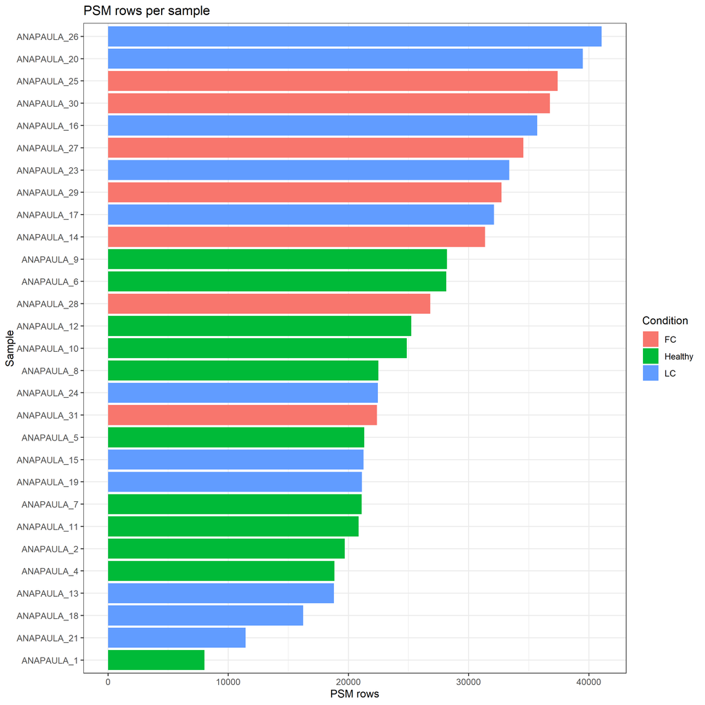

PSM counts for each sample before filtering, colored by experimental condition.

```r
psm |>
  count(SpectrumFile, name = "psms") |>
  left_join(annotation, by = c("SpectrumFile" = "Run")) |>
  ggplot(aes(x = reorder(FigureLabel, psms), y = psms, fill = Condition)) +
  geom_col() +
  coord_flip() +
  labs(x = "Sample", y = "PSM rows", title = "PSM rows per sample") +
  theme_bw()
```

## Raw Data QC

These checks look at the unfiltered PSM export. They are meant to catch run-level dropout, low-intensity samples, contaminant burden, shared peptide burden, and unexpected charge or modification patterns before any MSstats modeling.

```r
raw_intensity_qc <- psm |>
  left_join(annotation, by = c("SpectrumFile" = "Run")) |>
  group_by(.data$SpectrumFile, .data$FigureLabel, .data$Condition) |>
  summarise(
    psm_rows = n(),
    missing_intensity = sum(is.na(.data$`Quan Value`)),
    non_positive_intensity = sum(!is.na(.data$`Quan Value`) & .data$`Quan Value` <= 0),
    positive_intensity = sum(!is.na(.data$`Quan Value`) & .data$`Quan Value` > 0),
    missing_or_non_positive_percent =
      100 * (.data$missing_intensity + .data$non_positive_intensity) / .data$psm_rows,
    .groups = "drop"
  ) |>
  arrange(.data$Condition, .data$SpectrumFile)

knitr::kable(
  raw_intensity_qc,
  digits = 2,
  caption = "Raw intensity completeness and non-positive values by sample."
)
```

Raw intensity completeness and non-positive values by sample.

| SpectrumFile | FigureLabel | Condition | psm_rows | missing_intensity | non_positive_intensity | positive_intensity | missing_or_non_positive_percent |
| --- | --- | --- | --- | --- | --- | --- | --- |
| F14 | ANAPAULA_14 | FC | 31373 | 0 | 0 | 31373 | 0 |
| F25 | ANAPAULA_25 | FC | 37404 | 0 | 0 | 37404 | 0 |
| F27 | ANAPAULA_27 | FC | 34563 | 0 | 0 | 34563 | 0 |
| F28 | ANAPAULA_28 | FC | 26812 | 0 | 0 | 26812 | 0 |
| F29 | ANAPAULA_29 | FC | 32742 | 0 | 0 | 32742 | 0 |
| F30 | ANAPAULA_30 | FC | 36771 | 0 | 0 | 36771 | 0 |
| F31 | ANAPAULA_31 | FC | 22374 | 0 | 0 | 22374 | 0 |
| F1 | ANAPAULA_1 | Healthy | 8025 | 0 | 0 | 8025 | 0 |
| F10 | ANAPAULA_10 | Healthy | 24860 | 0 | 0 | 24860 | 0 |
| F11 | ANAPAULA_11 | Healthy | 20840 | 0 | 0 | 20840 | 0 |
| F12 | ANAPAULA_12 | Healthy | 25220 | 0 | 0 | 25220 | 0 |
| F2 | ANAPAULA_2 | Healthy | 19700 | 0 | 0 | 19700 | 0 |
| F4 | ANAPAULA_4 | Healthy | 18840 | 0 | 0 | 18840 | 0 |
| F5 | ANAPAULA_5 | Healthy | 21319 | 0 | 0 | 21319 | 0 |
| F6 | ANAPAULA_6 | Healthy | 28142 | 0 | 0 | 28142 | 0 |
| F7 | ANAPAULA_7 | Healthy | 21094 | 0 | 0 | 21094 | 0 |
| F8 | ANAPAULA_8 | Healthy | 22488 | 0 | 0 | 22488 | 0 |
| F9 | ANAPAULA_9 | Healthy | 28204 | 0 | 0 | 28204 | 0 |
| F13 | ANAPAULA_13 | LC | 18803 | 0 | 0 | 18803 | 0 |
| F15 | ANAPAULA_15 | LC | 21267 | 0 | 0 | 21267 | 0 |
| F16 | ANAPAULA_16 | LC | 35713 | 0 | 0 | 35713 | 0 |
| F17 | ANAPAULA_17 | LC | 32120 | 0 | 0 | 32120 | 0 |
| F18 | ANAPAULA_18 | LC | 16226 | 0 | 0 | 16226 | 0 |
| F19 | ANAPAULA_19 | LC | 21127 | 0 | 0 | 21127 | 0 |
| F20 | ANAPAULA_20 | LC | 39503 | 0 | 0 | 39503 | 0 |
| F21 | ANAPAULA_21 | LC | 11454 | 0 | 0 | 11454 | 0 |
| F23 | ANAPAULA_23 | LC | 33383 | 0 | 0 | 33383 | 0 |
| F24 | ANAPAULA_24 | LC | 22461 | 0 | 0 | 22461 | 0 |
| F26 | ANAPAULA_26 | LC | 41056 | 0 | 0 | 41056 | 0 |

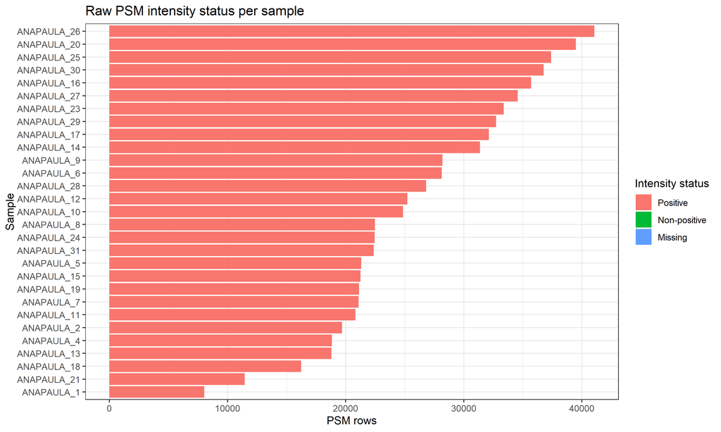

Raw PSM intensity-status counts per sample, separating positive, non-positive, and missing quantitative values.

```r
raw_intensity_qc |>
  tidyr::pivot_longer(
    cols = c("missing_intensity", "non_positive_intensity", "positive_intensity"),
    names_to = "status",
    values_to = "rows"
  ) |>
  mutate(
    status = factor(
      .data$status,
      levels = c("positive_intensity", "non_positive_intensity", "missing_intensity"),
      labels = c("Positive", "Non-positive", "Missing")
    )
  ) |>
  ggplot(aes(x = reorder(.data$FigureLabel, .data$rows), y = .data$rows, fill = .data$status)) +
  geom_col() +
  coord_flip() +
  labs(x = "Sample", y = "PSM rows", fill = "Intensity status",
       title = "Raw PSM intensity status per sample") +
  theme_bw()
```

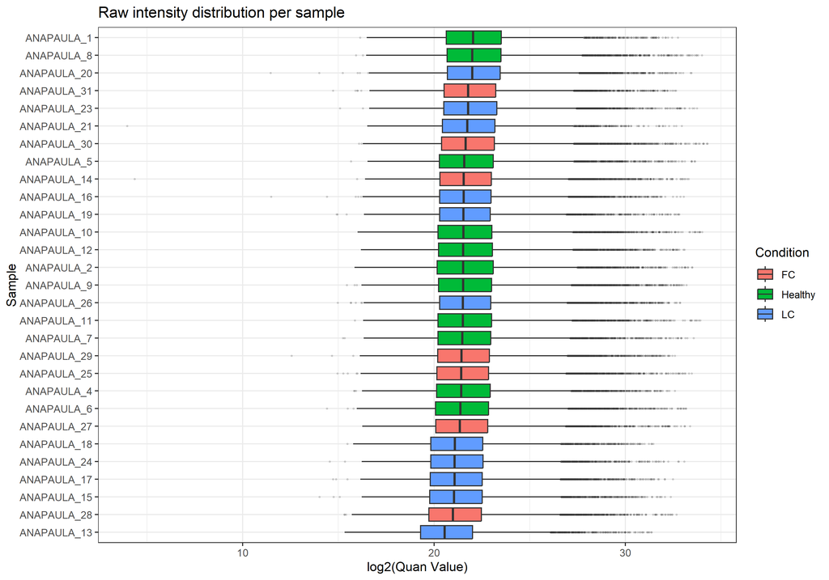

Distribution of raw log2 PSM intensities for each sample, colored by condition.

```r
psm |>
  filter(!is.na(.data$`Quan Value`), .data$`Quan Value` > 0) |>
  left_join(annotation, by = c("SpectrumFile" = "Run")) |>
  mutate(log2QuanValue = log2(.data$`Quan Value`)) |>
  ggplot(aes(x = reorder(.data$FigureLabel, .data$log2QuanValue, median),
             y = .data$log2QuanValue, fill = .data$Condition)) +
  geom_boxplot(outlier.alpha = 0.15, outlier.size = 0.4) +
  coord_flip() +
  labs(x = "Sample", y = "log2(Quan Value)",
       title = "Raw intensity distribution per sample") +
  theme_bw()
```

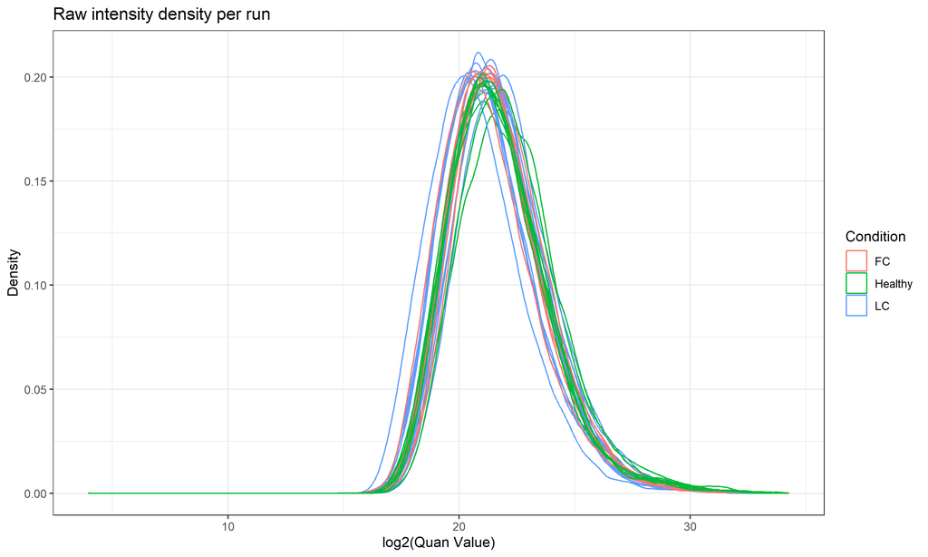

Kernel-density curves of raw log2 PSM intensities for each sample, colored by condition.

```r
psm |>
  filter(!is.na(.data$`Quan Value`), .data$`Quan Value` > 0) |>
  left_join(annotation, by = c("SpectrumFile" = "Run")) |>
  mutate(log2QuanValue = log2(.data$`Quan Value`)) |>
  ggplot(aes(x = .data$log2QuanValue, color = .data$Condition, group = .data$SpectrumFile)) +
  geom_density(alpha = 0.45, linewidth = 0.5) +
  labs(x = "log2(Quan Value)", y = "Density",
       title = "Raw intensity density per run") +
  theme_bw()
```

```r
contaminant_rows <- if ("Contaminant" %in% names(psm)) {
  sum(is_truthy_flag(psm$Contaminant))
} else {
  NA_integer_
}

shared_peptide_rows <- if ("# Proteins" %in% names(psm)) {
  sum(suppressWarnings(as.numeric(psm$`# Proteins`)) > 1, na.rm = TRUE)
} else {
  NA_integer_
}

single_peptide_proteins <- psm |>
  filter(!is.na(.data$`Master Protein Accessions`),
         !is.na(.data$`Annotated Sequence`)) |>
  distinct(.data$`Master Protein Accessions`, .data$`Annotated Sequence`) |>
  count(.data$`Master Protein Accessions`, name = "unique_peptides") |>
  summarise(n = sum(.data$unique_peptides == 1)) |>
  pull(.data$n)

tibble(
  metric = c(
    "Contaminant PSM rows",
    "Shared peptide PSM rows (# Proteins > 1)",
    "Proteins represented by one unique peptide"
  ),
  value = c(contaminant_rows, shared_peptide_rows, single_peptide_proteins)
) |>
  knitr::kable(
    caption = "Contaminant, shared-peptide, and single-peptide-protein summary."
  )
```

Contaminant, shared-peptide, and single-peptide-protein summary.

| metric | value |
| --- | --- |
| Contaminant PSM rows | 19837 |
| Shared peptide PSM rows (# Proteins > 1) | 66837 |
| Proteins represented by one unique peptide | 1850 |

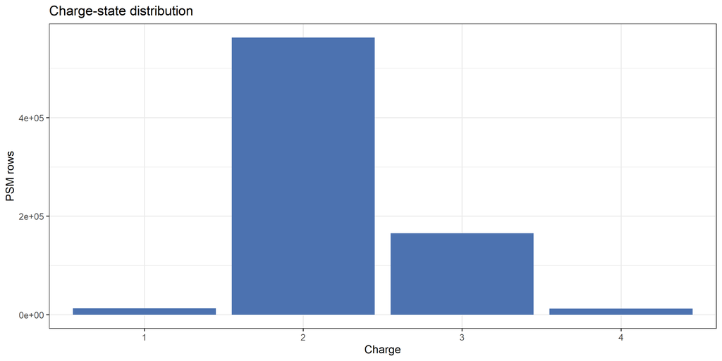

Raw PSM counts by precursor charge state.

```r
if ("Charge" %in% names(psm)) {
  psm |>
    mutate(Charge = as.character(.data$Charge)) |>
    count(.data$Charge, name = "psm_rows") |>
    ggplot(aes(x = .data$Charge, y = .data$psm_rows)) +
    geom_col(fill = "#4C72B0") +
    labs(x = "Charge", y = "PSM rows", title = "Charge-state distribution") +
    theme_bw()
} else {
  message("Charge-state plot skipped: Charge column was not found.")
}
```

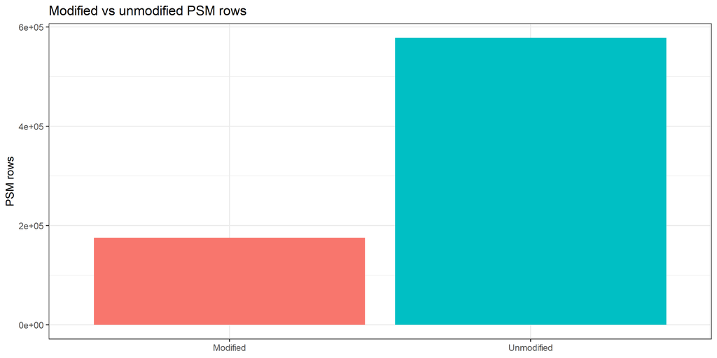

Raw PSM counts for modified and unmodified peptide-spectrum matches.

```r
if ("Modifications" %in% names(psm)) {
  psm |>
    mutate(
      modification_status = if_else(has_modification(.data$Modifications),
                                    "Modified", "Unmodified")
    ) |>
    count(.data$modification_status, name = "psm_rows") |>
    ggplot(aes(x = .data$modification_status, y = .data$psm_rows,
               fill = .data$modification_status)) +
    geom_col(show.legend = FALSE) +
    labs(x = NULL, y = "PSM rows", title = "Modified vs unmodified PSM rows") +
    theme_bw()
} else {
  message("Modification plot skipped: Modifications column was not found.")
}
```

## Preprocessing for MSstats

The PSM table is filtered before conversion. By default this report keeps high-confidence PSMs, removes rows flagged as contaminants when that column is present, and removes non-positive or missing intensities.

```r
psm_filtered <- psm |>
  filter(!is.na(`Quan Value`), `Quan Value` > 0)

if (!is.null(params$filter_confidence) && "Confidence" %in% names(psm_filtered)) {
  psm_filtered <- psm_filtered |>
    filter(.data$Confidence == params$filter_confidence)
}

if (isTRUE(params$remove_contaminants) && "Contaminant" %in% names(psm_filtered)) {
  psm_filtered <- psm_filtered |>
    filter(is.na(.data$Contaminant) | .data$Contaminant == FALSE)
}

preprocess_summary <- tibble(
  step = c("Raw PSM rows", "Rows after filtering"),
  rows = c(nrow(psm), nrow(psm_filtered))
)

knitr::kable(
  preprocess_summary,
  caption = "PSM row counts before and after MSstats input filtering."
)
```

PSM row counts before and after MSstats input filtering.

| step | rows |
| --- | --- |
| Raw PSM rows | 753884 |
| Rows after filtering | 734047 |

## Filtered Input QC

These summaries describe the data that will actually be submitted to `MSstats::PDtoMSstatsFormat()`.

```r
psm_filtered_features <- add_psm_feature_id(psm_filtered)

filtered_run_qc <- psm_filtered_features |>
  left_join(annotation, by = c("SpectrumFile" = "Run")) |>
  group_by(.data$SpectrumFile, .data$FigureLabel, .data$Condition) |>
  summarise(
    psm_rows = n(),
    annotated_sequences = n_distinct(.data$`Annotated Sequence`, na.rm = TRUE),
    peptide_charge_features = n_distinct(.data$.qc_feature_id, na.rm = TRUE),
    protein_accessions = n_distinct(.data$`Master Protein Accessions`, na.rm = TRUE),
    median_log2_intensity = median(log2(.data$`Quan Value`), na.rm = TRUE),
    .groups = "drop"
  ) |>
  arrange(.data$Condition, .data$SpectrumFile)

knitr::kable(
  filtered_run_qc,
  digits = 2,
  caption = "Filtered MSstats input features and intensities by sample."
)
```

Filtered MSstats input features and intensities by sample.

| SpectrumFile | FigureLabel | Condition | psm_rows | annotated_sequences | peptide_charge_features | protein_accessions | median_log2_intensity |
| --- | --- | --- | --- | --- | --- | --- | --- |
| F14 | ANAPAULA_14 | FC | 30616 | 28265 | 30616 | 5197 | 21.51 |
| F25 | ANAPAULA_25 | FC | 36610 | 34231 | 36610 | 5611 | 21.38 |
| F27 | ANAPAULA_27 | FC | 33811 | 31512 | 33811 | 5666 | 21.32 |
| F28 | ANAPAULA_28 | FC | 25989 | 24294 | 25989 | 4727 | 20.94 |
| F29 | ANAPAULA_29 | FC | 32054 | 29849 | 32054 | 5375 | 21.41 |
| F30 | ANAPAULA_30 | FC | 35855 | 32859 | 35855 | 5303 | 21.61 |
| F31 | ANAPAULA_31 | FC | 21888 | 20032 | 21888 | 4651 | 21.75 |
| F1 | ANAPAULA_1 | Healthy | 7632 | 7429 | 7632 | 1984 | 21.97 |
| F10 | ANAPAULA_10 | Healthy | 24135 | 22504 | 24135 | 4181 | 21.48 |
| F11 | ANAPAULA_11 | Healthy | 20078 | 18322 | 20078 | 3504 | 21.44 |
| F12 | ANAPAULA_12 | Healthy | 24419 | 22557 | 24419 | 3848 | 21.48 |
| F2 | ANAPAULA_2 | Healthy | 19122 | 17902 | 19122 | 3816 | 21.47 |
| F4 | ANAPAULA_4 | Healthy | 18153 | 17146 | 18153 | 3409 | 21.35 |
| F5 | ANAPAULA_5 | Healthy | 20768 | 19231 | 20768 | 4138 | 21.54 |
| F6 | ANAPAULA_6 | Healthy | 27221 | 24853 | 27221 | 3942 | 21.32 |
| F7 | ANAPAULA_7 | Healthy | 20281 | 18898 | 20281 | 3497 | 21.42 |
| F8 | ANAPAULA_8 | Healthy | 21807 | 20277 | 21807 | 4081 | 21.96 |
| F9 | ANAPAULA_9 | Healthy | 27399 | 25497 | 27399 | 4207 | 21.47 |
| F13 | ANAPAULA_13 | LC | 18217 | 17513 | 18217 | 3831 | 20.50 |
| F15 | ANAPAULA_15 | LC | 20729 | 19519 | 20729 | 4424 | 21.01 |
| F16 | ANAPAULA_16 | LC | 34944 | 32131 | 34944 | 5352 | 21.52 |
| F17 | ANAPAULA_17 | LC | 31390 | 29774 | 31390 | 5314 | 21.03 |
| F18 | ANAPAULA_18 | LC | 15796 | 14989 | 15796 | 3974 | 21.05 |
| F19 | ANAPAULA_19 | LC | 20662 | 19111 | 20662 | 4185 | 21.51 |
| F20 | ANAPAULA_20 | LC | 38712 | 35283 | 38712 | 5819 | 21.96 |
| F21 | ANAPAULA_21 | LC | 11159 | 10471 | 11159 | 3382 | 21.70 |
| F23 | ANAPAULA_23 | LC | 32688 | 30514 | 32688 | 5557 | 21.75 |
| F24 | ANAPAULA_24 | LC | 21788 | 20281 | 21788 | 4455 | 21.03 |
| F26 | ANAPAULA_26 | LC | 40124 | 36732 | 40124 | 5491 | 21.48 |

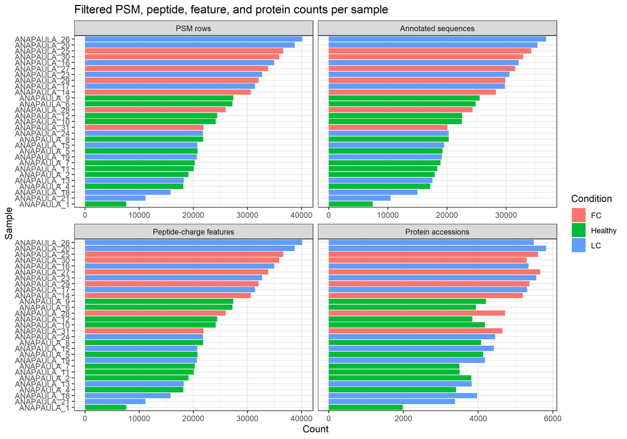

Filtered PSM, annotated-sequence, peptide-charge-feature, and protein-accession counts for each sample.

```r
filtered_run_qc |>
  select(SpectrumFile, FigureLabel, Condition, psm_rows, annotated_sequences,
         peptide_charge_features, protein_accessions) |>
  tidyr::pivot_longer(
    cols = c("psm_rows", "annotated_sequences",
             "peptide_charge_features", "protein_accessions"),
    names_to = "metric",
    values_to = "count"
  ) |>
  mutate(
    metric = factor(
      .data$metric,
      levels = c("psm_rows", "annotated_sequences",
                 "peptide_charge_features", "protein_accessions"),
      labels = c("PSM rows", "Annotated sequences",
                 "Peptide-charge features", "Protein accessions")
    )
  ) |>
  ggplot(aes(x = reorder(.data$FigureLabel, .data$count),
             y = .data$count, fill = .data$Condition)) +
  geom_col() +
  coord_flip() +
  facet_wrap(~ metric, scales = "free_x") +
  labs(x = "Sample", y = "Count",
       title = "Filtered PSM, peptide, feature, and protein counts per sample") +
  theme_bw()
```